# WeRateDogs

- Introduction
- Data Gathering
- Data Assessing
- Data Cleaning
- Finalizing
- References

## Introduction

WeRateDogs is a Twitter account that rates people's dogs with a humorous comment about the dog. These ratings almost always have a denominator of 10. The numerators, though? Almost always greater than 10. 11/10, 12/10, 13/10, etc. WeRateDogs has over 4 million followers and has received international media coverage. In this project, I will be doing data wrangling for constructing a clean dataset using the following steps:

1-Data gathering from different sources and using different methods  
2-Data assessing to document quality and tidiness issues.  
3-Data cleaning to use python libraries to get every assessed item corrected

Finally, I will be highlighting some insights from the final version of data set.

```python
import pandas as pd
import numpy as np
import requests
import os
import tweepy
import json
from datetime import datetime
import matplotlib.pyplot as plt
%matplotlib inline
```

### Data Gathering

> 1-WeRateDogs Twitter archive. The file downloaded manually 'twitter_archive_enhanced.csv'.

> 2-The tweet image predictions, i.e., what breed of dog (or other object, animal, etc.).The file downloaded programmatically using the Requests library and the following URL: https://d17h27t6h515a5.cloudfront.net/topher/2017/August/599fd2ad_image-predictions/image-predictions.tsv.

> 3-Gathering additional data using Twitter's API. Having the WeRateDogs Twitter archive and specifically the tweet IDs within it, can gather this data. I will store each tweet's entire set of JSON data in a file called tweet_json.txt file.

#### Data gathering 1

`twitter-archive-enhanced.csv`

```python
#read csv file to build archive enhanced tweets dataframe
twt_arc_enh_df = pd.read_csv('twitter-archive-enhanced.csv')
```

#### Data gathering 2

`image-predictions.tsv`

```python
#programtically download image predictions tsv file
url = 'https://d17h27t6h515a5.cloudfront.net/topher/2017/August/599fd2ad_image-predictions/image-predictions.tsv'
response = requests.get(url)
with open(url.split('/')[-1], mode = 'wb') as file:
    file.write(response.content)
```

```python
#convert image predictions tsv file to dataframe
img_pred_df = pd.read_csv('image-predictions.tsv', sep='\t')
```

#### Data gathering 3

`tweet_json.txt`

```python
#get missing values for tweets in twitter archive enhanced file usin tweepy API
consumer_key =
consumer_secret =
access_token =
access_secret =

auth = tweepy.OAuthHandler(consumer_key, consumer_secret)
auth.set_access_token(access_token, access_secret)

api = tweepy.API(auth,wait_on_rate_limit = True, wait_on_rate_limit_notify = True)
```

```python
#deleted tweets will be stored in a list
missing_tweet = []
#Get tweets json data using tweet_id
tweet_ids = list(twt_arc_enh_df.tweet_id)
with open('tweet_json.txt', mode='a', encoding='utf8') as file:
    for twt_id in tweet_ids:
        try:
            tweet = api.get_status(twt_id, tweet_mode = 'extended')
            #each tweet JSON data in a separate line
            json.dump(tweet._json,file)
            file.write('\n')
        except Exception as e:
            print(str(twt_id) + ": " + str(e))
            missing_tweet.append(str(twt_id))
```

```
888202515573088257: [{'code': 144, 'message': 'No status found with that ID.'}]
873697596434513921: [{'code': 144, 'message': 'No status found with that ID.'}]
872668790621863937: [{'code': 144, 'message': 'No status found with that ID.'}]
869988702071779329: [{'code': 144, 'message': 'No status found with that ID.'}]
866816280283807744: [{'code': 144, 'message': 'No status found with that ID.'}]
861769973181624320: [{'code': 144, 'message': 'No status found with that ID.'}]
845459076796616705: [{'code': 144, 'message': 'No status found with that ID.'}]
842892208864923648: [{'code': 144, 'message': 'No status found with that ID.'}]
837012587749474308: [{'code': 144, 'message': 'No status found with that ID.'}]
827228250799742977: [{'code': 144, 'message': 'No status found with that ID.'}]
812747805718642688: [{'code': 144, 'message': 'No status found with that ID.'}]
802247111496568832: [{'code': 144, 'message': 'No status found with that ID.'}]
775096608509886464: [{'code': 144, 'message': 'No status found with that ID.'}]
770743923962707968: [{'code': 144, 'message': 'No status found with that ID.'}]
```

```
Rate limit reached. Sleeping for: 295
```

```
754011816964026368: [{'code': 144, 'message': 'No status found with that ID.'}]
680055455951884288: [{'code': 144, 'message': 'No status found with that ID.'}]
```

```
Rate limit reached. Sleeping for: 317
```

```python
#store tweets JSON data then convert it to a dataframe
json_tweets = []
with open('tweet_json2.txt',encoding='utf-8') as json_file:
    #read JSON file line by line
    for line in json_file:
        data = json.loads(line)
        json_tweets.append({'tweet_id':data['id_str'],
                           'favorite_count':data['favorite_count'],
                           'retweet_count':data['retweet_count']})
json_tweets_df = pd.DataFrame(json_tweets, columns = ['tweet_id', 'favorite_count', 'retweet_count'])
```

## Data Assessing

#### Data assessing 1

`enhanced twitter archive`  
**twt_arc_enh_df**

```python
twt_arc_enh_df.sample(5)
```

|  | tweet_id | in_reply_to_status_id | in_reply_to_user_id | timestamp | source | text | retweeted_status_id | retweeted_status_user_id | retweeted_status_timestamp | expanded_urls | rating_numerator | rating_denominator | name | doggo | floofer | pupper | puppo |
| --- | --- | --- | --- | --- | --- | --- | --- | --- | --- | --- | --- | --- | --- | --- | --- | --- | --- |
| 234 | 847617282490613760 | 8.476062e+17 | 4.196984e+09 | 2017-03-31 01:11:22 +0000 | <a href="http://twitter.com/download/iphone" r... | .@breaannanicolee PUPDATE: Cannon has a heart ... | NaN | NaN | NaN | NaN | 13 | 10 | None | None | None | None | None |
| 427 | 821153421864615936 | 8.211526e+17 | 1.132119e+08 | 2017-01-17 00:33:26 +0000 | <a href="http://twitter.com/download/iphone" r... | @imgur for a polar bear tho I'd say 13/10 is a... | NaN | NaN | NaN | NaN | 13 | 10 | None | None | None | None | None |
| 1729 | 679862121895714818 | NaN | NaN | 2015-12-24 03:12:15 +0000 | <a href="http://twitter.com/download/iphone" r... | "Dammit hooman I'm jus trynna lik the fler" 11... | NaN | NaN | NaN | https://twitter.com/dog_rates/status/679862121... | 11 | 10 | None | None | None | None | None |
| 1526 | 690374419777196032 | NaN | NaN | 2016-01-22 03:24:22 +0000 | <a href="http://twitter.com/download/iphone" r... | This is Phred. He's an Albanian Flepperkush. T... | NaN | NaN | NaN | https://twitter.com/dog_rates/status/690374419... | 11 | 10 | Phred | None | None | None | None |
| 70 | 879008229531029506 | NaN | NaN | 2017-06-25 16:07:47 +0000 | <a href="http://twitter.com/download/iphone" r... | This is Beau. That is Beau's balloon. He takes... | NaN | NaN | NaN | https://twitter.com/dog_rates/status/879008229... | 13 | 10 | Beau | None | None | None | None |

```python
twt_arc_enh_df.shape
```

```
(2356, 17)
```

```python
twt_arc_enh_df.info()
```

```
<class 'pandas.core.frame.DataFrame'>
RangeIndex: 2356 entries, 0 to 2355
Data columns (total 17 columns):
tweet_id                      2356 non-null int64
in_reply_to_status_id         78 non-null float64
in_reply_to_user_id           78 non-null float64
timestamp                     2356 non-null object
source                        2356 non-null object
text                          2356 non-null object
retweeted_status_id           181 non-null float64
retweeted_status_user_id      181 non-null float64
retweeted_status_timestamp    181 non-null object
expanded_urls                 2297 non-null object
rating_numerator              2356 non-null int64
rating_denominator            2356 non-null int64
name                          2356 non-null object
doggo                         2356 non-null object
floofer                       2356 non-null object
pupper                        2356 non-null object
puppo                         2356 non-null object
dtypes: float64(4), int64(3), object(10)
memory usage: 313.0+ KB
```

```python
twt_arc_enh_df.retweeted_status_id.isnull().value_counts()
```

```
True     2175
False     181
Name: retweeted_status_id, dtype: int64
```

```python
twt_arc_enh_df.name.value_counts()
```

```
None         745
a             55
Charlie       12
Oliver        11
Lucy          11
Cooper        11
Tucker        10
Lola          10
Penny         10
Bo             9
Winston        9
the            8
Sadie          8
an             7
Buddy          7
Toby           7
Bailey         7
Daisy          7
Scout          6
Milo           6
Bella          6
Oscar          6
Jack           6
Rusty          6
Stanley        6
Leo            6
Jax            6
Dave           6
Koda           6
Sunny          5
            ...
Banjo          1
Augie          1
Karl           1
Bookstore      1
Stuart         1
Mutt           1
old            1
Flurpson       1
Erik           1
Dante          1
Emmie          1
Bayley         1
Laela          1
Mark           1
Rupert         1
Pawnd          1
Sunshine       1
Skittles       1
Millie         1
Joshwa         1
Traviss        1
Arya           1
Marvin         1
Alf            1
Dylan          1
Ralphson       1
Damon          1
his            1
DayZ           1
Champ          1
Name: name, Length: 957, dtype: int64
```

```python
twt_arc_enh_df.source.value_counts()
```

```
<a href="http://twitter.com/download/iphone" rel="nofollow">Twitter for iPhone</a>     2221
<a href="http://vine.co" rel="nofollow">Vine - Make a Scene</a>                          91
<a href="http://twitter.com" rel="nofollow">Twitter Web Client</a>                       33
<a href="https://about.twitter.com/products/tweetdeck" rel="nofollow">TweetDeck</a>      11
Name: source, dtype: int64
```

#### Data assessing 2

`image prediction`  
**img_pred_df**

```python
img_pred_df.sample(5)
```

|  | tweet_id | jpg_url | img_num | p1 | p1_conf | p1_dog | p2 | p2_conf | p2_dog | p3 | p3_conf | p3_dog |
| --- | --- | --- | --- | --- | --- | --- | --- | --- | --- | --- | --- | --- |
| 1988 | 872820683541237760 | https://pbs.twimg.com/media/DBzhx0PWAAEhl0E.jpg | 3 | pug | 0.999120 | True | French_bulldog | 0.000552 | True | bull_mastiff | 0.000073 | True |
| 1995 | 874296783580663808 | https://pbs.twimg.com/media/DCIgSR0XgAANEOY.jpg | 1 | cocker_spaniel | 0.437216 | True | miniature_poodle | 0.277191 | True | toy_poodle | 0.157402 | True |
| 880 | 698635131305795584 | https://pbs.twimg.com/ext_tw_video_thumb/69863... | 1 | Samoyed | 0.158464 | True | kuvasz | 0.089402 | True | West_Highland_white_terrier | 0.025037 | True |
| 516 | 676430933382295552 | https://pbs.twimg.com/media/CWMqV7WUYAEEClG.jpg | 1 | golden_retriever | 0.583875 | True | cocker_spaniel | 0.203671 | True | Labrador_retriever | 0.036122 | True |
| 615 | 680176173301628928 | https://pbs.twimg.com/media/CXB4nWnWEAAhLTX.jpg | 1 | Christmas_stocking | 0.207547 | False | mask | 0.193880 | False | feather_boa | 0.152738 | False |

```python
img_pred_df.shape
```

```
(2075, 12)
```

```python
img_pred_df.info()
```

```
<class 'pandas.core.frame.DataFrame'>
RangeIndex: 2075 entries, 0 to 2074
Data columns (total 12 columns):
tweet_id    2075 non-null int64
jpg_url     2075 non-null object
img_num     2075 non-null int64
p1          2075 non-null object
p1_conf     2075 non-null float64
p1_dog      2075 non-null bool
p2          2075 non-null object
p2_conf     2075 non-null float64
p2_dog      2075 non-null bool
p3          2075 non-null object
p3_conf     2075 non-null float64
p3_dog      2075 non-null bool
dtypes: bool(3), float64(3), int64(2), object(4)
memory usage: 152.1+ KB
```

```python
img_pred_df.tweet_id.duplicated().value_counts()
```

```
False    2075
Name: tweet_id, dtype: int64
```

```python
img_pred_df.jpg_url.duplicated().value_counts()
```

```
False    2009
True       66
Name: jpg_url, dtype: int64
```

#### Data assessing 3

`twitter JSON information`  
**json_tweets_df**

```python
json_tweets_df.info()
```

```
<class 'pandas.core.frame.DataFrame'>
RangeIndex: 2340 entries, 0 to 2339
Data columns (total 3 columns):
tweet_id          2340 non-null object
favorite_count    2340 non-null int64
retweet_count     2340 non-null int64
dtypes: int64(2), object(1)
memory usage: 54.9+ KB
```

```python
json_tweets_df.sample(5)
```

|  | tweet_id | favorite_count | retweet_count |
| --- | --- | --- | --- |
| 36 | 885167619883638784 | 21424 | 4267 |
| 1737 | 678800283649069056 | 2673 | 954 |
| 1966 | 672968025906282496 | 1330 | 558 |
| 1150 | 722974582966214656 | 4254 | 1653 |
| 648 | 791312159183634433 | 9370 | 2772 |

```python
json_tweets_df.shape
```

```
(2340, 3)
```

#### Quality

`twt_arc_enh_df`

- Hyperlinks for sources in `source` column.
- Retweeted rows not needed.
- Rows with no image not needed.
- Data type of `timestampe` column.
- Data type of `tweet_id` should be string.
- Some names in `name` column have words like(a, an, the, his, this ...etc)
- Missing tweets will have no json data.

`img_pred_df`

- Duplicated urls in `jpg_url` column.
- Data type of `tweet_id` should be string.
- Dog predictions have underscore separation.
- Dog predictions have small letters.

#### Tidiness

`twt_arc_enh_df`

- last four columns representing dog stage.

`img_pred_df`

- Dog prediction should be decided in one column.
- Confidence levels should be in one column.

## Data Cleaning

```python
#new dataframes for safe cleaning
twt_arc_enh_clean = twt_arc_enh_df.copy()
json_tweets_clean = json_tweets_df.copy()
img_pred_clean = img_pred_df.copy()
```

#### `twt_arc_enh` : Missing tweets will have no json data

##### Define

*Delete records that couldn't be found when downloading twitter JSON information.*

##### Code

```python
#missing_tweet=['888202515573088257',
# '873697596434513921',
# '872668790621863937',
# '869988702071779329',
# '866816280283807744',
# '861769973181624320',
# '845459076796616705',
# '842892208864923648',
# '837012587749474308',
# '827228250799742977',
# '812747805718642688',
# '802247111496568832',
# '775096608509886464',
# '770743923962707968',
# '754011816964026368',
# '680055455951884288']
len(missing_tweet)
```

```
16
```

```python
twt_arc_enh_clean = twt_arc_enh_clean[~twt_arc_enh_clean['tweet_id'].isin(missing_tweet)]
#twt_arc_enh_clean.reset_index(inplace=True, drop=True)
```

##### Test

```python
twt_arc_enh_clean.shape
```

```
(2340, 17)
```

#### `twt_arc_enh`: Some names in name column have words like(a, an, the, his, this ...etc)

##### Define

Repace lower case words with **None**. Some dog names which are not actual names and I noticed that they are all lower case words.

##### Code

```python
twt_arc_enh_clean['name'] = twt_arc_enh_clean['name'].str.replace('^[a-z]+$','None')
#for i in range(len(arc_enh_clean.tweet_id)):
#    if arc_enh_clean.name[i].islower():
#        arc_enh_clean.name[i] = 'None'
```

##### Test

```python
twt_arc_enh_clean.name.value_counts()
```

```
None        846
Lucy         11
Cooper       11
Charlie      11
Oliver       11
Tucker       10
Penny        10
Lola         10
Bo            9
Winston       9
Sadie         8
Toby          7
Buddy         7
Daisy         7
Bailey        7
Jack          6
Rusty         6
Dave          6
Jax           6
Leo           6
Koda          6
Milo          6
Stanley       6
Bella         6
Oscar         6
Scout         6
Finn          5
Chester       5
Louis         5
Bentley       5
           ...
Billl         1
Lacy          1
Fiji          1
Banjo         1
Augie         1
Flurpson      1
DayZ          1
Stella        1
Sunshine      1
Opie          1
Derby         1
Dante         1
Emmie         1
Bayley        1
Laela         1
Mark          1
Rupert        1
Pawnd         1
Rooney        1
Clifford      1
Erik          1
Millie        1
Arya          1
Marvin        1
Alf           1
Dylan         1
Stephan       1
Ralphson      1
Damon         1
Champ         1
Name: name, Length: 932, dtype: int64
```

#### `twt_arc_enh`: Retweeted rows not needed

#### Define

##### Code

```python
twt_arc_enh_clean = twt_arc_enh_clean[twt_arc_enh_clean.retweeted_status_id.isnull()]
```

##### Test

```python
twt_arc_enh_clean.info()
```

```
<class 'pandas.core.frame.DataFrame'>
Int64Index: 2173 entries, 0 to 2355
Data columns (total 17 columns):
tweet_id                      2173 non-null int64
in_reply_to_status_id         78 non-null float64
in_reply_to_user_id           78 non-null float64
timestamp                     2173 non-null object
source                        2173 non-null object
text                          2173 non-null object
retweeted_status_id           0 non-null float64
retweeted_status_user_id      0 non-null float64
retweeted_status_timestamp    0 non-null object
expanded_urls                 2115 non-null object
rating_numerator              2173 non-null int64
rating_denominator            2173 non-null int64
name                          2173 non-null object
doggo                         2173 non-null object
floofer                       2173 non-null object
pupper                        2173 non-null object
puppo                         2173 non-null object
dtypes: float64(4), int64(3), object(10)
memory usage: 305.6+ KB
```

```python
#reset index
twt_arc_enh_clean.reset_index(inplace=True, drop=True)
twt_arc_enh_clean.shape
```

```
(2173, 17)
```

#### `twt_arc_enh`: Data type of tweet_id should be string

##### Define

*Covert `tweet_id` from int to string*

##### Code

```python
twt_arc_enh_clean.tweet_id = twt_arc_enh_clean.tweet_id.astype(str)
```

##### Test

```python
twt_arc_enh_clean.tweet_id.head(1)
```

```
0    892420643555336193
Name: tweet_id, dtype: object
```

#### `twt_arc_enh`: Data type of timestampe column

##### Define

*Convert `timestampe` from string to datetime.*

##### Code

```python
twt_arc_enh_clean.timestamp = pd.to_datetime(twt_arc_enh_clean.timestamp)
```

##### Test

```python
twt_arc_enh_clean.timestamp.head(1)
```

```
0   2017-08-01 16:23:56
Name: timestamp, dtype: datetime64[ns]
```

#### `twt_arc_enh`: Rows with no image not needed

##### Define

*Delete records with `expanded_urls` null values.*

##### Code

```python
twt_arc_enh_clean = twt_arc_enh_clean[~(twt_arc_enh_clean.expanded_urls.isnull())]
```

##### Test

```python
twt_arc_enh_clean.info()
```

```
<class 'pandas.core.frame.DataFrame'>
Int64Index: 2115 entries, 0 to 2172
Data columns (total 17 columns):
tweet_id                      2115 non-null object
in_reply_to_status_id         23 non-null float64
in_reply_to_user_id           23 non-null float64
timestamp                     2115 non-null datetime64[ns]
source                        2115 non-null object
text                          2115 non-null object
retweeted_status_id           0 non-null float64
retweeted_status_user_id      0 non-null float64
retweeted_status_timestamp    0 non-null object
expanded_urls                 2115 non-null object
rating_numerator              2115 non-null int64
rating_denominator            2115 non-null int64
name                          2115 non-null object
doggo                         2115 non-null object
floofer                       2115 non-null object
pupper                        2115 non-null object
puppo                         2115 non-null object
dtypes: datetime64[ns](1), float64(4), int64(2), object(10)
memory usage: 297.4+ KB
```

```python
#reset index
twt_arc_enh_clean.reset_index(inplace=True, drop=True)
twt_arc_enh_clean.shape
```

```
(2115, 17)
```

#### `twt_arc_enh`: Hyperlinks for sources in source column

##### Define

*Extract twitter sources form `source` column*

##### Code

```python
twt_arc_enh_clean['source'] = twt_arc_enh_clean.source.str.extract(r'>+([A-Za-z- ._]+)',expand=True)
```

##### Test

```python
twt_arc_enh_clean.source.value_counts()
```

```
Twitter for iPhone     1984
Vine - Make a Scene      91
Twitter Web Client       30
TweetDeck                10
Name: source, dtype: int64
```

#### `twt_arc_enh`: last four columns representing dog stage

##### Define

Get record of all possible combinations for the last 4 columns and then make a list of it.  
Map the list to right dog stage.

##### Code

```python
twt_arc_enh_clean['dog_stage'] = \
twt_arc_enh_clean[twt_arc_enh_clean.columns[13:]].apply(lambda x: ','.join(x.astype(str)),axis=1)
```

```python
twt_arc_enh_clean.dog_stage.value_counts()
```

```
None,None,None,None        1777
None,None,pupper,None       222
doggo,None,None,None         72
None,None,None,puppo         23
doggo,None,pupper,None       10
None,floofer,None,None        9
doggo,floofer,None,None       1
doggo,None,None,puppo         1
Name: dog_stage, dtype: int64
```

**Note**  
*single mixed dog stages above "last 2" were visually chechek from `text` column to get the right dog stage. While for the 10 mixed dog stages doggo and pupper, I decided to make it 'None' because most probably they are 2 dogs in same tweet*

```python
mapping_dict = {'None,None,None,None':'None',
                'None,None,pupper,None':'pupper',
                'doggo,None,None,None':'doggo',
                'None,None,None,puppo':'puppo',
                'doggo,None,pupper,None':'None',
                'None,floofer,None,None':'floofer',
                'doggo,floofer,None,None':'floofer',
                'doggo,None,None,puppo':'puppo'}
```

```python
twt_arc_enh_clean.assign(dog_stage = twt_arc_enh_clean.dog_stage.replace(mapping_dict, inplace=True));
```

##### Test

```python
twt_arc_enh_clean.sample(5)
```

|  | tweet_id | in_reply_to_status_id | in_reply_to_user_id | timestamp | source | text | retweeted_status_id | retweeted_status_user_id | retweeted_status_timestamp | expanded_urls | rating_numerator | rating_denominator | name | doggo | floofer | pupper | puppo | dog_stage |
| --- | --- | --- | --- | --- | --- | --- | --- | --- | --- | --- | --- | --- | --- | --- | --- | --- | --- | --- |
| 1178 | 700002074055016451 | NaN | NaN | 2016-02-17 17:01:14 | Twitter for iPhone | This is Thumas. He covered himself in nanners ... | NaN | NaN | NaN | https://twitter.com/dog_rates/status/700002074... | 9 | 10 | Thumas | None | None | None | None | None |
| 641 | 768855141948723200 | NaN | NaN | 2016-08-25 16:58:45 | Twitter for iPhone | This is Jesse. He really wants a belly rub. Wi... | NaN | NaN | NaN | https://twitter.com/dog_rates/status/768855141... | 11 | 10 | Jesse | None | None | None | None | None |
| 87 | 872820683541237760 | NaN | NaN | 2017-06-08 14:20:41 | Twitter for iPhone | Here are my favorite #dogsatpollingstations \n... | NaN | NaN | NaN | https://twitter.com/dog_rates/status/872820683... | 13 | 10 | None | None | None | None | None | None |
| 1151 | 702598099714314240 | NaN | NaN | 2016-02-24 20:56:55 | Twitter for iPhone | This is Sansa. She's gotten too big for her ch... | NaN | NaN | NaN | https://twitter.com/dog_rates/status/702598099... | 11 | 10 | Sansa | None | None | pupper | None | pupper |
| 186 | 848212111729840128 | NaN | NaN | 2017-04-01 16:35:01 | Twitter for iPhone | This is Jerry. He's doing a distinguished tong... | NaN | NaN | NaN | https://twitter.com/dog_rates/status/848212111... | 6 | 10 | Jerry | None | None | None | None | None |

```python
twt_arc_enh_clean.dog_stage.value_counts()
```

```
None       1787
pupper      222
doggo        72
puppo        24
floofer      10
Name: dog_stage, dtype: int64
```

*Drop unneeded columns*

```python
twt_arc_enh_clean.drop(['in_reply_to_status_id','in_reply_to_user_id',
                    'retweeted_status_id','retweeted_status_user_id',
                    'retweeted_status_timestamp','doggo','floofer','pupper','puppo'], axis=1, inplace=True)
twt_arc_enh_clean.info()
```

```
<class 'pandas.core.frame.DataFrame'>
RangeIndex: 2115 entries, 0 to 2114
Data columns (total 9 columns):
tweet_id              2115 non-null object
timestamp             2115 non-null datetime64[ns]
source                2115 non-null object
text                  2115 non-null object
expanded_urls         2115 non-null object
rating_numerator      2115 non-null int64
rating_denominator    2115 non-null int64
name                  2115 non-null object
dog_stage             2115 non-null object
dtypes: datetime64[ns](1), int64(2), object(6)
memory usage: 148.8+ KB
```

```python
twt_arc_enh_clean.shape
```

```
(2115, 9)
```

#### `img_pred`: Data type of `tweet_id`should be string

##### Define

*Covert `tweet_id` from int to string*

##### Code

```python
img_pred_clean.tweet_id = img_pred_clean.tweet_id.astype(str)
```

##### Test

```python
img_pred_clean.tweet_id.dtype
```

```
dtype('O')
```

#### `img_pred`: Duplicated urls in jpg_url column

##### Define

*Remove duplicated records using `jpg_url` column*

##### Code

```python
img_pred_clean.drop_duplicates('jpg_url',inplace=True)
```

##### Test

```python
img_pred_clean.jpg_url.duplicated().count()
```

```
2009
```

```python
img_pred_clean.shape
```

```
(2009, 12)
```

#### `img_pred`: Dog prediction should be decided in one column

#### `img_pred`: Confidence levels should be in one column

##### Define

*I will do both in one action. I'll define a function when I apply it to `img_pred` I should have the right prediction as well as the confidence level. If no prediction 'None' found then I make confidence level equals zero*

##### Code

```python
#2 lists for prediction final result and the corresponding confidence level
pred = []
conf = []
def dog_pred(df):
    if df.p1_dog:
        pred.append(df.p1)
        conf.append(df.p1_conf)
    elif df.p2_dog:
        pred.append(df.p2)
        conf.append(df.p2_conf)
    elif df.p3_dog:
        pred.append(df.p3)
        conf.append(df.p3_conf)
    else:
        pred.append('None')
        conf.append(0)

#Apply the function to img_pred dataframe
img_pred_clean.apply(dog_pred, axis=1)
#Create 2 new columns dog_prediction and confidence for the resuls in the 2 lists
img_pred_clean['dog_prediction'] = pred
img_pred_clean['confidence'] = conf
```

##### Test

```python
img_pred_clean.tail(5)
```

|  | tweet_id | jpg_url | img_num | p1 | p1_conf | p1_dog | p2 | p2_conf | p2_dog | p3 | p3_conf | p3_dog | dog_prediction | confidence |
| --- | --- | --- | --- | --- | --- | --- | --- | --- | --- | --- | --- | --- | --- | --- |
| 2070 | 891327558926688256 | https://pbs.twimg.com/media/DF6hr6BUMAAzZgT.jpg | 2 | basset | 0.555712 | True | English_springer | 0.225770 | True | German_short-haired_pointer | 0.175219 | True | basset | 0.555712 |
| 2071 | 891689557279858688 | https://pbs.twimg.com/media/DF_q7IAWsAEuuN8.jpg | 1 | paper_towel | 0.170278 | False | Labrador_retriever | 0.168086 | True | spatula | 0.040836 | False | Labrador_retriever | 0.168086 |
| 2072 | 891815181378084864 | https://pbs.twimg.com/media/DGBdLU1WsAANxJ9.jpg | 1 | Chihuahua | 0.716012 | True | malamute | 0.078253 | True | kelpie | 0.031379 | True | Chihuahua | 0.716012 |
| 2073 | 892177421306343426 | https://pbs.twimg.com/media/DGGmoV4XsAAUL6n.jpg | 1 | Chihuahua | 0.323581 | True | Pekinese | 0.090647 | True | papillon | 0.068957 | True | Chihuahua | 0.323581 |
| 2074 | 892420643555336193 | https://pbs.twimg.com/media/DGKD1-bXoAAIAUK.jpg | 1 | orange | 0.097049 | False | bagel | 0.085851 | False | banana | 0.076110 | False | None | 0.000000 |

*Drop unneeded columns*

```python
img_pred_clean.drop(['p1','p1_conf','p1_dog','p2','p2_conf','p2_dog','p3','p3_conf','p3_dog'], axis=1, inplace=True);
```

#### `img_red`: Dog predictions have underscore separation

##### Define

*Remove the underscore from colum `dog_predection` values and replace it with a space*

##### Code

```python
img_pred_clean.dog_prediction = img_pred_clean.dog_prediction.str.replace('_',' ')
```

##### Test

```python
img_pred_clean.dog_prediction.sample(5)
```

```
1164    Staffordshire bullterrier
1876                      Samoyed
1124                    Chihuahua
530            Labrador retriever
1291           Labrador retriever
Name: dog_prediction, dtype: object
```

#### `img_pred`: Dog predictions have small letters

##### Define

*Correct `dog_pred` valuse to start all word with capital letter.*

##### Code

```python
img_pred_clean.dog_prediction = img_pred_clean.dog_prediction.str.title()
```

```python
img_pred_clean.dog_prediction.value_counts()
```

```
None                              318
Golden Retriever                  158
Labrador Retriever                108
Pembroke                           95
Chihuahua                          91
Pug                                63
Toy Poodle                         51
Chow                               48
Samoyed                            42
Pomeranian                         42
Malamute                           33
French Bulldog                     31
Chesapeake Bay Retriever           31
Cocker Spaniel                     30
Miniature Pinscher                 25
Eskimo Dog                         22
Staffordshire Bullterrier          21
Cardigan                           21
German Shepherd                    21
Siberian Husky                     20
Beagle                             20
Shih-Tzu                           20
Maltese Dog                        19
Shetland Sheepdog                  19
Rottweiler                         19
Kuvasz                             19
Lakeland Terrier                   18
Basset                             17
Italian Greyhound                  17
American Staffordshire Terrier     16
                                 ...
Gordon Setter                       4
Giant Schnauzer                     4
Bluetick                            4
Tibetan Terrier                     4
Keeshond                            4
Welsh Springer Spaniel              4
Briard                              3
Curly-Coated Retriever              3
Cairn                               3
Brabancon Griffon                   3
Toy Terrier                         3
Irish Water Spaniel                 3
Komondor                            3
Afghan Hound                        3
Leonberg                            3
Greater Swiss Mountain Dog          3
Australian Terrier                  2
Black-And-Tan Coonhound             2
Groenendael                         2
Wire-Haired Fox Terrier             2
Sussex Spaniel                      2
Appenzeller                         2
Bouvier Des Flandres                1
Japanese Spaniel                    1
Standard Schnauzer                  1
Entlebucher                         1
Silky Terrier                       1
Clumber                             1
Scotch Terrier                      1
Irish Wolfhound                     1
Name: dog_prediction, Length: 114, dtype: int64
```

```python
#reset index
img_pred_clean.reset_index(inplace=True, drop=True)
img_pred_clean.info()
```

```
<class 'pandas.core.frame.DataFrame'>
RangeIndex: 2009 entries, 0 to 2008
Data columns (total 5 columns):
tweet_id          2009 non-null object
jpg_url           2009 non-null object
img_num           2009 non-null int64
dog_prediction    2009 non-null object
confidence        2009 non-null float64
dtypes: float64(1), int64(1), object(3)
memory usage: 78.6+ KB
```

```python
merged_df = pd.merge(twt_arc_enh_clean, json_tweets_clean, on='tweet_id')
```

```python
merged_df.info()
```

```
<class 'pandas.core.frame.DataFrame'>
Int64Index: 2115 entries, 0 to 2114
Data columns (total 11 columns):
tweet_id              2115 non-null object
timestamp             2115 non-null datetime64[ns]
source                2115 non-null object
text                  2115 non-null object
expanded_urls         2115 non-null object
rating_numerator      2115 non-null int64
rating_denominator    2115 non-null int64
name                  2115 non-null object
dog_stage             2115 non-null object
favorite_count        2115 non-null int64
retweet_count         2115 non-null int64
dtypes: datetime64[ns](1), int64(4), object(6)
memory usage: 198.3+ KB
```

## Finalilzing

*Now let's bring it all together and merge the 3 dataframes into one then save it to a file `twitter_archive_master.csv`*

```python
merged_df = pd.merge(merged_df, img_pred_clean, on='tweet_id')
```

```python
merged_df.info()
```

```
<class 'pandas.core.frame.DataFrame'>
Int64Index: 1992 entries, 0 to 1991
Data columns (total 15 columns):
tweet_id              1992 non-null object
timestamp             1992 non-null datetime64[ns]
source                1992 non-null object
text                  1992 non-null object
expanded_urls         1992 non-null object
rating_numerator      1992 non-null int64
rating_denominator    1992 non-null int64
name                  1992 non-null object
dog_stage             1992 non-null object
favorite_count        1992 non-null int64
retweet_count         1992 non-null int64
jpg_url               1992 non-null object
img_num               1992 non-null int64
dog_prediction        1992 non-null object
confidence            1992 non-null float64
dtypes: datetime64[ns](1), float64(1), int64(5), object(8)
memory usage: 249.0+ KB
```

```python
merged_df.to_csv('twitter_archive_master.csv', index=False)
```

**Looking at the favourited tweet count distribution**

```python
merged_df.favorite_count.describe()
```

```
count      1992.000000
mean       8687.330321
std       12742.536415
min          78.000000
25%        1862.750000
50%        3929.000000
75%       10824.000000
max      163487.000000
Name: favorite_count, dtype: float64
```

```python
merged_df[merged_df['favorite_count'] == merged_df['favorite_count'].max()]
```

|  | tweet_id | timestamp | source | text | expanded_urls | rating_numerator | rating_denominator | name | dog_stage | favorite_count | retweet_count | jpg_url | img_num | dog_prediction | confidence |
| --- | --- | --- | --- | --- | --- | --- | --- | --- | --- | --- | --- | --- | --- | --- | --- |
| 774 | 744234799360020481 | 2016-06-18 18:26:18 | Twitter for iPhone | Here's a doggo realizing you can stand in a po... | https://twitter.com/dog_rates/status/744234799... | 13 | 10 | None | doggo | 163487 | 83127 | https://pbs.twimg.com/ext_tw_video_thumb/74423... | 1 | Labrador Retriever | 0.825333 |

*Labrador Retriver of a stage 'doggo' but has no name has obtained hieghest favourite count*

**Looking at the retweeted tweet count distribution**

```python
merged_df.retweet_count.describe()
```

```
count     1992.000000
mean      2634.647088
std       4697.233255
min         11.000000
25%        588.000000
50%       1265.000000
75%       3019.250000
max      83127.000000
Name: retweet_count, dtype: float64
```

```python
merged_df[merged_df['retweet_count'] == merged_df['retweet_count'].max()]
```

|  | tweet_id | timestamp | source | text | expanded_urls | rating_numerator | rating_denominator | name | dog_stage | favorite_count | retweet_count | jpg_url | img_num | dog_prediction | confidence |
| --- | --- | --- | --- | --- | --- | --- | --- | --- | --- | --- | --- | --- | --- | --- | --- |
| 774 | 744234799360020481 | 2016-06-18 18:26:18 | Twitter for iPhone | Here's a doggo realizing you can stand in a po... | https://twitter.com/dog_rates/status/744234799... | 13 | 10 | None | doggo | 163487 | 83127 | https://pbs.twimg.com/ext_tw_video_thumb/74423... | 1 | Labrador Retriever | 0.825333 |

*The same dog has obtained hieghest retweet count*

**Let's see the confidence level distribution**

```python
merged_df.confidence.describe()
```

```
count    1992.000000
mean        0.464656
std         0.339419
min         0.000000
25%         0.140339
50%         0.458209
75%         0.776359
max         0.999956
Name: confidence, dtype: float64
```

```python
merged_df[merged_df['confidence'] == merged_df['confidence'].max()]
```

|  | tweet_id | timestamp | source | text | expanded_urls | rating_numerator | rating_denominator | name | dog_stage | favorite_count | retweet_count | jpg_url | img_num | dog_prediction | confidence |
| --- | --- | --- | --- | --- | --- | --- | --- | --- | --- | --- | --- | --- | --- | --- | --- |
| 1844 | 668636665813057536 | 2015-11-23 03:46:18 | Twitter for iPhone | This is an Irish Rigatoni terrier named Berta.... | https://twitter.com/dog_rates/status/668636665... | 10 | 10 | None | None | 1051 | 497 | https://pbs.twimg.com/media/CUd5gBGWwAA0IVA.jpg | 1 | Komondor | 0.999956 |

*Komondor with undefined dog stage has the hieghest confidence level*

**Visualizing count of dog stages excluding the undefined**

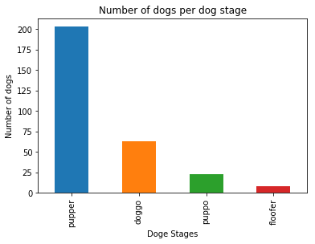

```python
df = merged_df[merged_df['dog_stage']!='None']
df.dog_stage.value_counts().plot(kind='bar')
plt.xlabel('Doge Stages')
plt.ylabel('Number of dogs')
plt.title('Number of dogs per dog stage');
```

## References

- http://pandas.pydata.org/pandas-docs/stable/getting_started/dsintro.html
- https://stackoverflow.com/questions/20250771/remap-values-in-pandas-column-with-a-dict
- https://stackoverflow.com/questions/27965295/dropping-rows-from-dataframe-based-on-a-not-in-condition
- https://stackoverflow.com/questions/50599934/removing-rows-from-dataframe-whose-first-letter-is-in-lowercase
- https://docs.python.org/3/library/datetime.html